# Montag children’s book corpus

training w2v on corpus

Molly Lewis

2018-03-23

FINDINGS:

- The N closest words to “boy” and “girl” are almost non-overlapping, suggesting that the concepts of maleness and femaleness are located in different parts of semantic space (maybe related to valence?)
- There are more male-biased books than female-biased books (61% vs. 39%).
- There’s less variability in semantic space for female-biased books, compared to male-biased books.

## Train word2vec model on montag corpus.

### Book centroids

This is the distribution of books in semantic space using t-sne coordinates. The cenroid of each book is calculated as the sum of all words in book.

```r
model_df <- read_csv("w2v_montag_corpus.csv")

montag_counts <- read_csv("tidy_montag_corpus.csv") %>%
  rename(target_word = word) %>%
  count(title, target_word)

# get location of essay in the vector space
get_one_essay_location <- function(book_title,
                                   model,
                                   book_data){

  # merge current essay with corresponding word vecs
  merged_vectors <- book_data[title == book_title] %>%
    merge(model, all.x = TRUE, by = "target_word")

  # get pieces to essay vector computation
  word_vectors <- merged_vectors %>%  # get word vectors only
    select(V1:V200) %>%
    as.matrix()
  counts <- merged_vectors$n # get counts

  # weighted by number of times word appears in essay
  count_weighted_vecs <- word_vectors * counts # weight by n word appears
  essay_vector_count_weighted <- t(colSums(count_weighted_vecs,
                                           na.rm = TRUE)) # sum across words

  # return essay vector
  count_weighting_vec <- data.frame(title = book_title,
                                    essay_vector_count_weighted)

}

essay_locations <-
  map_df(unique(montag_counts$title),
         get_one_essay_location, model_df,
         as.data.table(montag_counts))

# get tsne coordinates
tsne_out = Rtsne::Rtsne(as.matrix(essay_locations[,-1]))
tsne_dims <- tsne_out$Y %>%
  as.data.frame() %>%
  rename(tsne_X = V1,
         tsne_Y = V2)

#write_csv(tsne_dims, "book_tsne_montag_w2v.csv")
```

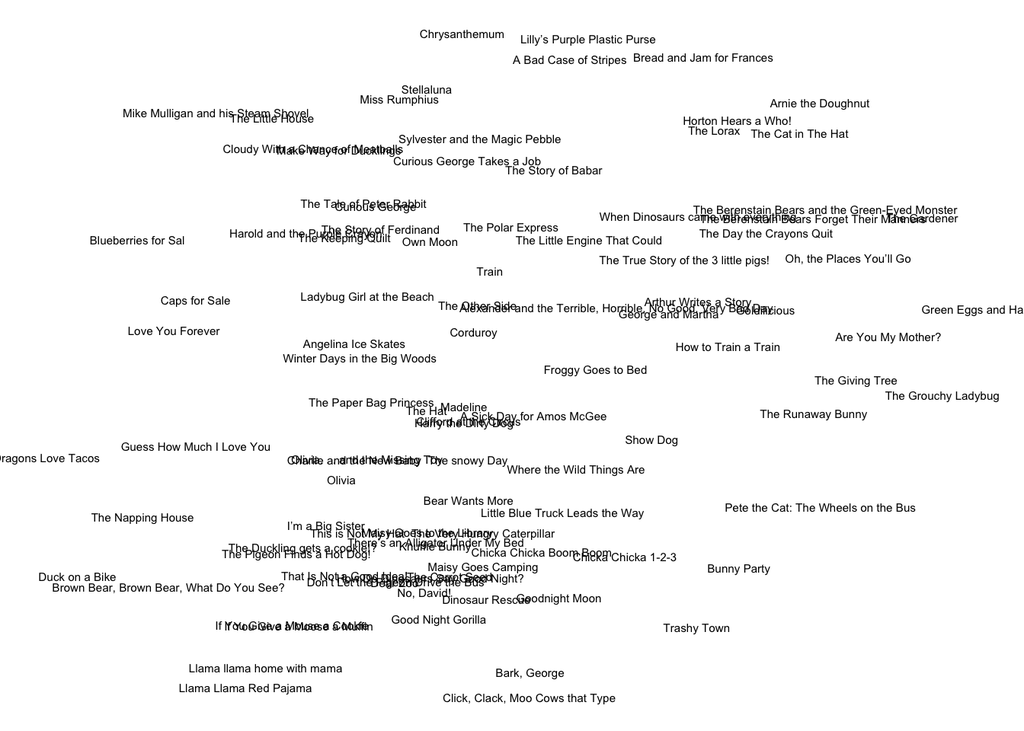

```r
tsne_dims <- read_csv("book_tsne_montag_w2v.csv") %>%
  bind_cols(title = unique(montag_counts$title))

ggplot(tsne_dims,
         aes(x = tsne_X, y = tsne_Y)) +
  geom_text(aes(label = title), size = 2) +
  theme_void()
```

## Relative position of gender-related words

Get N closest words (N = 200) to “boy” and “girl” word pairs. Then, plot in 2d space and try to predict words with independent ratings (Glasglow and Byrsbaert).

```r
# Read in w2v and norms.
gender_norms <- read_csv("GlasgowNorms.csv") %>%
  select(word, GEND_M) %>%
  rename(gender_maleness = GEND_M)

affect_norms <- read_csv("BRM-emot-submit.csv") %>%
  select(2,3,6,9) %>%
  rename(word = Word,
         valence = V.Mean.Sum,
         affect = A.Mean.Sum,
         dominance = D.Mean.Sum)
```

### Boy vs. girl

#### Distribution in 2d w2v space

The large point corresponds to the target boy and girl words.

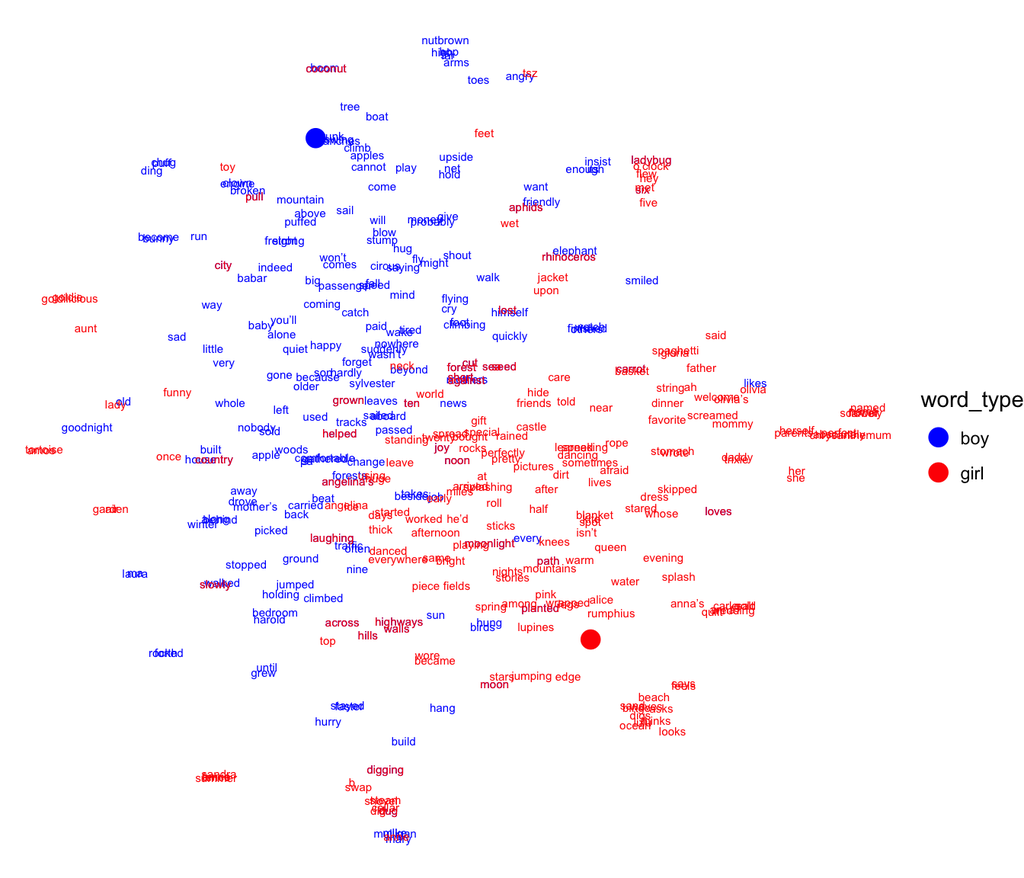

```r
BOY_WORD <- "boy"
GIRL_WORD <- "girl"

boy_words <- model %>%
  closest_to(BOY_WORD, n = 201, fancy_names = F) %>%
  slice(-1) %>%
  mutate(word_type = "boy")
  #mutate(word = text_tokens(word, stemmer = "en") %>% unlist())

girl_words <- model %>%
  closest_to(GIRL_WORD, n = 201, fancy_names = F) %>%
  slice(-1) %>%
  mutate(word_type = "girl")
  #mutate(word = text_tokens(word, stemmer = "en") %>% unlist())

word_dims <- boy_words %>%
  bind_rows(girl_words) %>%
  select(-similarity, -word_type) %>%
  add_row(word = GIRL_WORD) %>%
  add_row(word = BOY_WORD) %>%
  rename(target_word = word) %>%
  left_join(model_df) %>%
  distinct(target_word, .keep_all=T)

# get tsne coordinates
tsne_out = Rtsne::Rtsne(as.matrix(word_dims[,-1]))
tsne_dims <- tsne_out$Y %>%
  as.data.frame() %>%
  rename(tsne_X = V1,
         tsne_Y = V2)  %>%
  bind_cols(target_word = word_dims$target_word) %>%
  select(target_word, everything())

tsne_words <- boy_words %>%
  bind_rows(girl_words) %>%
  select(-similarity) %>%
  rename(target_word = word) %>%
  left_join(tsne_dims)

targ_words <- tsne_dims %>%
  filter(target_word %in% c(BOY_WORD, GIRL_WORD)) %>%
  mutate(word_type = ifelse(target_word == BOY_WORD,
                            "boy", "girl"))

ggplot(tsne_words,
         aes(x = tsne_X, y = tsne_Y)) +
  geom_text(aes(label = target_word, color = word_type),
            size = 2) +
  scale_color_manual(values = c("blue", "red")) +
  geom_point(aes(color = word_type),
             data = targ_words, size = 4) +
  theme_void()
```

#### Independent ratings

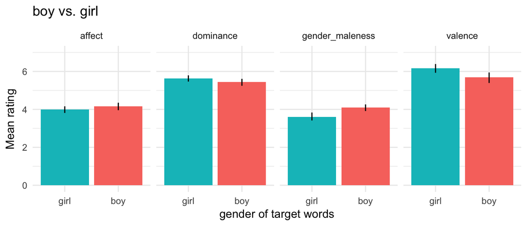

```r
boy_words %>%
  bind_rows(girl_words) %>%
  left_join(gender_norms) %>%
  left_join(affect_norms) %>%
  gather("norm", "rating", -1:-3) %>%
  group_by(norm, word_type) %>%
  multi_boot_standard(col = "rating", na.rm = T) %>%
  ggplot(aes(x = fct_rev(word_type), y = mean,
             fill = word_type)) +
    facet_wrap(~norm, nrow = 1) +
    geom_bar(stat = "identity") +
    ggtitle(paste0(BOY_WORD, " vs. ", GIRL_WORD)) +
    ylab("Mean rating") +
    xlab("gender of target words") +
    ylim(0, 7) +
    geom_linerange(aes(ymin = ci_lower, ymax = ci_upper)) +
    theme_minimal() +
    theme(legend.position = "none")
```

### Him vs. her

#### Distribution in 2d w2v space

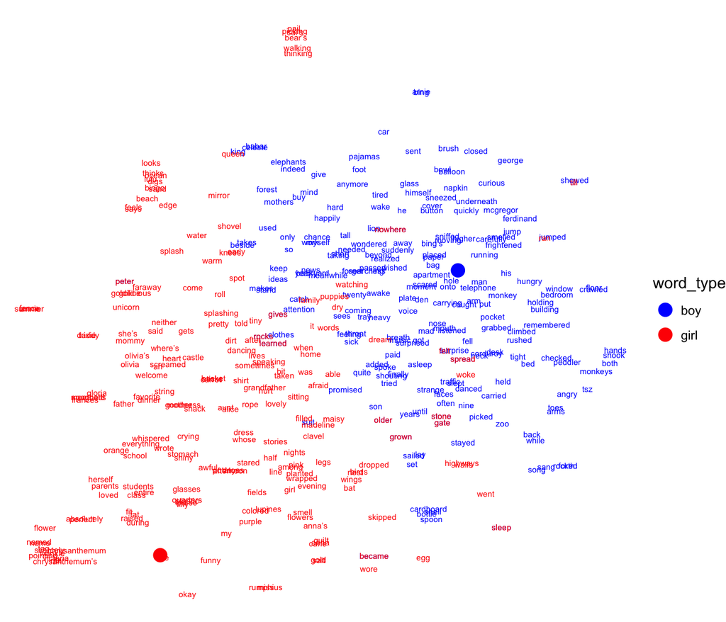

```r
BOY_WORD <- "him"
GIRL_WORD <- "her"

boy_words <- model %>%
  closest_to(BOY_WORD, n = 201, fancy_names = F) %>%
  slice(-1) %>%
  mutate(word_type = "boy")
  #mutate(word = text_tokens(word, stemmer = "en") %>% unlist())

girl_words <- model %>%
  closest_to(GIRL_WORD, n = 201, fancy_names = F) %>%
  slice(-1) %>%
  mutate(word_type = "girl")
  #mutate(word = text_tokens(word, stemmer = "en") %>% unlist())

word_dims <- boy_words %>%
  bind_rows(girl_words) %>%
  select(-similarity, -word_type) %>%
  add_row(word = GIRL_WORD) %>%
  add_row(word = BOY_WORD) %>%
  rename(target_word = word) %>%
  left_join(model_df) %>%
  distinct(target_word, .keep_all=T)

# get tsne coordinates
tsne_out = Rtsne::Rtsne(as.matrix(word_dims[,-1]))
tsne_dims <- tsne_out$Y %>%
  as.data.frame() %>%
  rename(tsne_X = V1,
         tsne_Y = V2)  %>%
  bind_cols(target_word = word_dims$target_word) %>%
  select(target_word, everything())

tsne_words <- boy_words %>%
  bind_rows(girl_words) %>%
  select(-similarity) %>%
  rename(target_word = word) %>%
  left_join(tsne_dims)

targ_words <- tsne_dims %>%
  filter(target_word %in% c(BOY_WORD, GIRL_WORD)) %>%
  mutate(word_type = ifelse(target_word == BOY_WORD,
                            "boy", "girl"))

ggplot(tsne_words,
         aes(x = tsne_X, y = tsne_Y)) +
  geom_text(aes(label = target_word, color = word_type),
            size = 2) +
  scale_color_manual(values = c("blue", "red")) +
  geom_point(aes(color = word_type),
             data = targ_words, size = 4) +
  theme_void()
```

#### Independent ratings

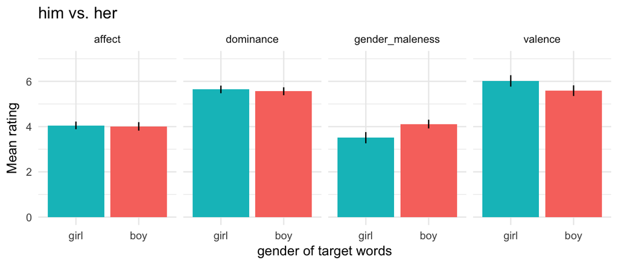

```r
boy_words %>%
  bind_rows(girl_words) %>%
  left_join(gender_norms) %>%
  left_join(affect_norms) %>%
  gather("norm", "rating", -1:-3) %>%
  group_by(norm, word_type) %>%
  multi_boot_standard(col = "rating", na.rm = T) %>%
  ggplot(aes(x = fct_rev(word_type), y = mean,
             fill = word_type)) +
    facet_wrap(~norm, nrow = 1) +
    geom_bar(stat = "identity") +
    ggtitle(paste0(BOY_WORD, " vs. ", GIRL_WORD)) +
    ylab("Mean rating") +
    ylim(0, 7) +
    xlab("gender of target words") +

    geom_linerange(aes(ymin = ci_lower, ymax = ci_upper)) +
    theme_minimal() +
    theme(legend.position = "none")
```

### His vs. her

#### Distribution in 2d w2v space

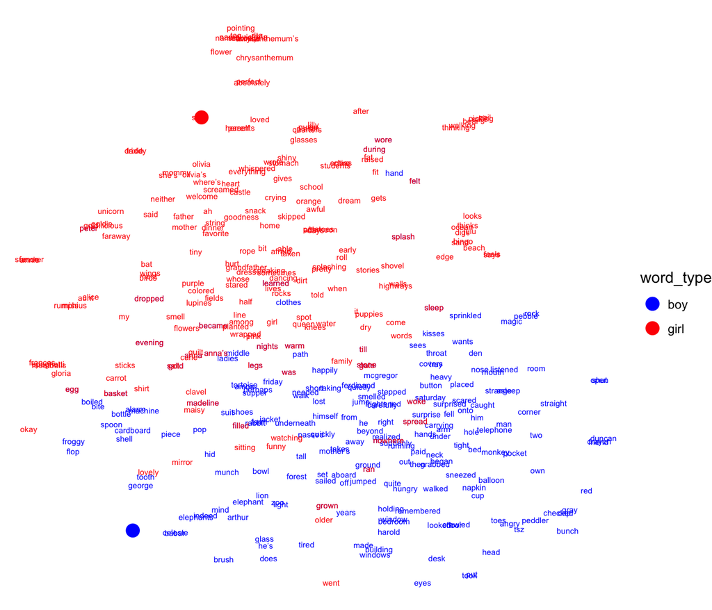

```r
BOY_WORD <- "his"
GIRL_WORD <- "her"

boy_words <- model %>%
  closest_to(BOY_WORD, n = 201, fancy_names = F) %>%
  slice(-1) %>%
  mutate(word_type = "boy")
  #mutate(word = text_tokens(word, stemmer = "en") %>% unlist())

girl_words <- model %>%
  closest_to(GIRL_WORD, n = 201, fancy_names = F) %>%
  slice(-1) %>%
  mutate(word_type = "girl")
  #mutate(word = text_tokens(word, stemmer = "en") %>% unlist())

word_dims <- boy_words %>%
  bind_rows(girl_words) %>%
  select(-similarity, -word_type) %>%
  add_row(word = GIRL_WORD) %>%
  add_row(word = BOY_WORD) %>%
  rename(target_word = word) %>%
  left_join(model_df) %>%
  distinct(target_word, .keep_all=T)

# get tsne coordinates
tsne_out = Rtsne::Rtsne(as.matrix(word_dims[,-1]))
tsne_dims <- tsne_out$Y %>%
  as.data.frame() %>%
  rename(tsne_X = V1,
         tsne_Y = V2)  %>%
  bind_cols(target_word = word_dims$target_word) %>%
  select(target_word, everything())

tsne_words <- boy_words %>%
  bind_rows(girl_words) %>%
  select(-similarity) %>%
  rename(target_word = word) %>%
  left_join(tsne_dims)

targ_words <- tsne_dims %>%
  filter(target_word %in% c(BOY_WORD, GIRL_WORD)) %>%
  mutate(word_type = ifelse(target_word == BOY_WORD,
                            "boy", "girl"))

ggplot(tsne_words,
         aes(x = tsne_X, y = tsne_Y)) +
  geom_text(aes(label = target_word, color = word_type),
            size = 2) +
  scale_color_manual(values = c("blue", "red")) +
  geom_point(aes(color = word_type),
             data = targ_words, size = 4) +
  theme_void()
```

#### Independent ratings

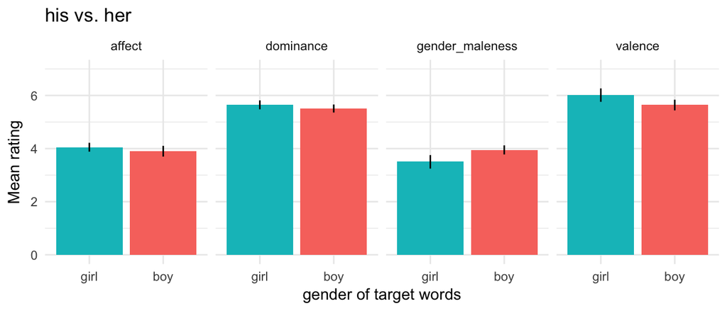

```r
boy_words %>%
  bind_rows(girl_words) %>%
  left_join(gender_norms) %>%
  left_join(affect_norms) %>%
  gather("norm", "rating", -1:-3) %>%
  group_by(norm, word_type) %>%
  multi_boot_standard(col = "rating", na.rm = T) %>%
  ggplot(aes(x = fct_rev(word_type), y = mean,
             fill = word_type)) +
    facet_wrap(~norm, nrow = 1) +
    geom_bar(stat = "identity") +
    ggtitle(paste0(BOY_WORD, " vs. ", GIRL_WORD)) +
    ylab("Mean rating") +
    xlab("gender of target words") +
    ylim(0, 7) +
    geom_linerange(aes(ymin = ci_lower, ymax = ci_upper)) +
    theme_minimal() +
    theme(legend.position = "none")
```

## Gender score of each word

To calculate gender bias score for each word, I took the mean distance to 4 “male” words (“boy”, “man”, “he”, “him”) and the mean distance to 4 “female” words (“girl”, “woman”, “she”, “her”), and subtracted the two. Positive numbers indicate male bias.

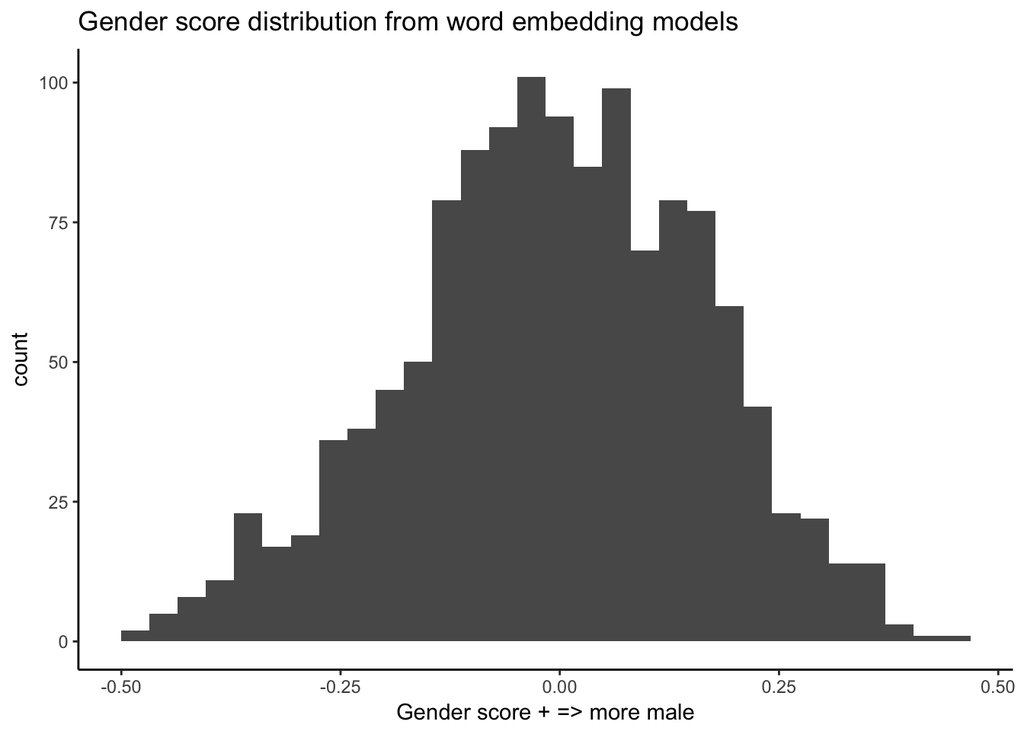

```r
w2v_norms <- read_csv("gender_score_output_montag_trained.csv",
                      col_names = c("target_word", "female_score",
                                    "male_score", "gender_score")) %>%
  distinct(.keep_all = T) %>%
  anti_join(stop_words %>% filter(lexicon == "SMART"),
            by = c("target_word" = "word"))

ggplot(w2v_norms, aes(x = gender_score)) +
    ggtitle("Gender score distribution from word embedding models")+
  xlab("Gender score + => more male") +
    geom_histogram() +
    theme_classic()
```

Glasglow norms:

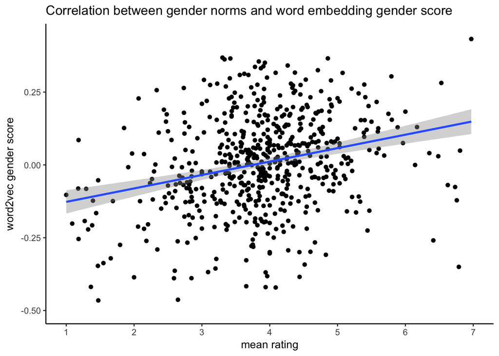

```r
norms <- read_csv("GlasgowNorms.csv") %>%
  select(word, GEND_M, contains("_M"))

all_norms <- left_join(w2v_norms, norms, by = c("target_word"= "word")) %>%
  rename(gender_rating = GEND_M) %>%
  select(target_word, gender_score, gender_rating)


ggplot(all_norms,aes(y = gender_score, x = gender_rating)) +
    geom_point() +
    geom_smooth(method = "lm")  +
    ggtitle("Correlation between gender norms and word embedding gender score")+
    ylab("word2vec gender score") +
    scale_x_continuous(name = "mean rating",
                     limits = c(1, 7),
                     breaks = 1:7) +
  theme_classic()
```

```r
cor_summary <- cor.test(all_norms$gender_score, all_norms$gender_rating)
cor_summary
```

```
##
##  Pearson's product-moment correlation
##
## data:  all_norms$gender_score and all_norms$gender_rating
## t = 6.9028, df = 586, p-value = 1.329e-11
## alternative hypothesis: true correlation is not equal to 0
## 95 percent confidence interval:
##  0.1977479 0.3473762
## sample estimates:
##       cor
## 0.2742209
```

These are correlated with the Glasglow norms, though not as strongly as when using the Wikipedia-trained corpus.

## Gender score by book

```r
montag <- read_csv("tidy_montag_corpus.csv") %>%
  rename(target_word = word)

tidy_with_norms <- montag %>%
  left_join(w2v_norms)

norm_means <- tidy_with_norms %>%
  group_by(title) %>%
  multi_boot_standard(col = "gender_score", na.rm = T)

norm_means_wide <- norm_means %>%
  select(title, mean) %>%
  arrange(mean)

kable(norm_means_wide, "html") %>%
  kable_styling() %>%
  scroll_box(width = "900px", height = "400px")
```

| title | mean |
| --- | --- |
| Chrysanthemum | -0.2227945 |
| Ladybug Girl at the Beach | -0.1717888 |
| Olivia | -0.1559726 |
| The Other Side | -0.1403173 |
| Bread and Jam for Frances | -0.1326910 |
| Knuffle Bunny | -0.1258607 |
| Olivia. . . and the Missing Toy | -0.1219377 |
| The Keeping Quilt | -0.1141147 |
| A Bad Case of Stripes | -0.1125367 |
| Lilly’s Purple Plastic Purse | -0.1109904 |
| Goldilicious | -0.1070088 |
| Miss Rumphius | -0.1057535 |
| Blueberries for Sal | -0.0969059 |
| The Pigeon Finds a Hot Dog! | -0.0916011 |
| Charlie and the New Baby | -0.0694802 |
| Angelina Ice Skates | -0.0671414 |
| Stellaluna | -0.0607183 |
| The Napping House | -0.0578504 |
| Madeline | -0.0549459 |
| I’m a Big Sister | -0.0542753 |
| Cloudy With a Chance of Meatballs | -0.0516419 |
| Brown Bear, Brown Bear, What Do You See? | -0.0405251 |
| Show Dog | -0.0391585 |
| The Gardener | -0.0343828 |
| The Little House | -0.0316518 |
| The Berenstain Bears and the Green-Eyed Monster | -0.0292539 |
| Maisy Goes to the Library | -0.0289920 |
| The Grouchy Ladybug | -0.0281236 |
| The Very Hungry Caterpillar | -0.0269398 |
| Mike Mulligan and his Steam Shovel | -0.0225999 |

[output cut: 70 more lines]

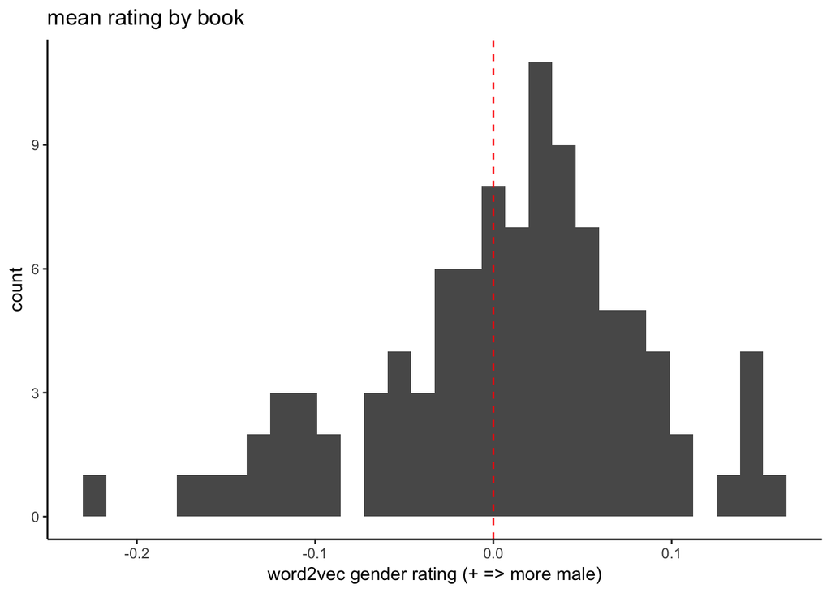

```r
ggplot(norm_means_wide, aes(x = mean)) +
    geom_histogram() +
    ggtitle("mean rating by book") +
    xlab("word2vec gender rating (+ => more male)") +
    geom_vline(aes(xintercept = 0), color = "red", linetype = 2) +
    theme_classic()
```

```r
#norm_means_wide %>%
 # mutate(male = ifelse(mean > 0, 1, 0)) %>%
 # ungroup()%>%
 # count(male)
```

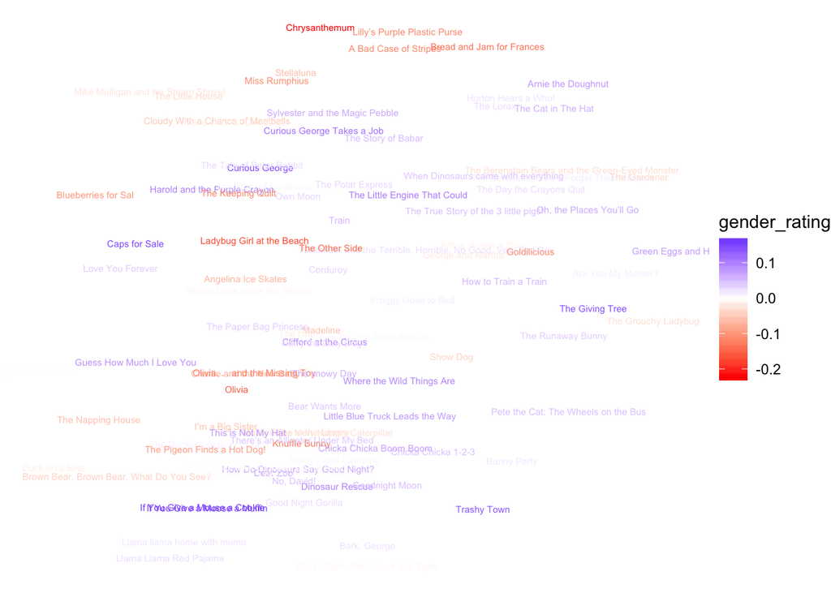

```r
tsne_dims <- read_csv("book_tsne_montag_w2v.csv") %>%
  bind_cols(gender_rating = norm_means$mean)  %>%
  bind_cols(title = norm_means$title)  %>%
  mutate(gender_rating_cat = ifelse(gender_rating > 0,
                                    "male", "female"))


  ggplot(tsne_dims,
         aes(x = tsne_X, y = tsne_Y, color = gender_rating)) +
  geom_text(aes(label = title, color = gender_rating), size = 2) +
  #geom_point() +
  scale_color_gradient2(low = "red", high = "blue") +
    theme_void()
```

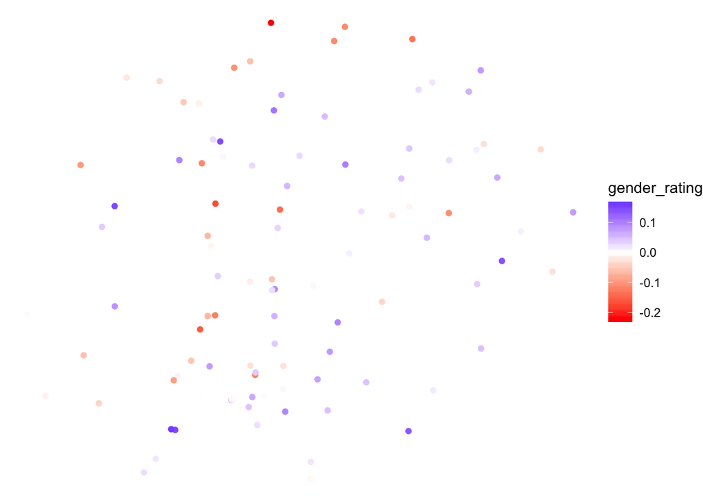

```r
  ggplot(tsne_dims,
         aes(x = tsne_X, y = tsne_Y, color = gender_rating)) +
    geom_point() +
  #geom_text(aes(label = title, color = gender_rating), size = 2) +
  #geom_point() +
  scale_color_gradient2(low = "red", high = "blue") +
    theme_void()
```